# Predicting Recidivism

Cole Evarts, Jake Garmo, Joshua Weimer, Lilly Amirjavadi

2/11/2021

## Introduction

We will be using linear regression, logistic regression, LASSO regression, and Ridge regression to predict recidivism based on the provided dataset. We will then optimize each model individually. Finally, from the optimized models, we will select the optimal model that best predicts recidivism. We will determine the “best” model by measuring accuracy, precision, recall, and false positive rate.

We will treat the cost of falsely predicting someone to recidivate as equal to the cost of falsely predicting someone to not recidivate. However, this does not mean we will only measure accuracy. We do not want to disproportionately fasely flag, but we also do not want to disproportionately not flag. Therefore, we will try to find an optimal point that tries to maximize all three metrics without treating one as the most important.

## Data and Preprocessing

We will subset the data into a training set and a testing set. 70% of the data will go to the training set and 30% of the data will be used for testing.

```r
# read in data and remove ID var
dat <- read.csv("C:/Users/garmo/Downloads/recidivism_data_sample.csv")
dat <- dat[,-1]

# factorize race and charge name
dat$race <- factor(dat$race)
dat$charge_name <- factor(dat$charge_name)

# sample the data into train and test
n.total <- length(dat$recidivate)
prop.train <- 0.7
set.seed(1)
r <- sample(1:n.total,round(prop.train*n.total), replace = FALSE)
```

## Linear Regression

Linear regression will be the simplest alogrithm used in this report. We do not expect linear to be accurate as it is not designed to evaluate binary outcomes. Both linear and logistic regression models will also pick up more noise than Lasoo and Ridge as the former do not have penalty functions. This means they will not reduce the coefficients of irrelevant predictors.

Although linear regression is typically evaluated my means squared error, this measure is not useful for evaluating binary classification. Therefore, we will only report the binary classification metrics as mentioned in the intro.

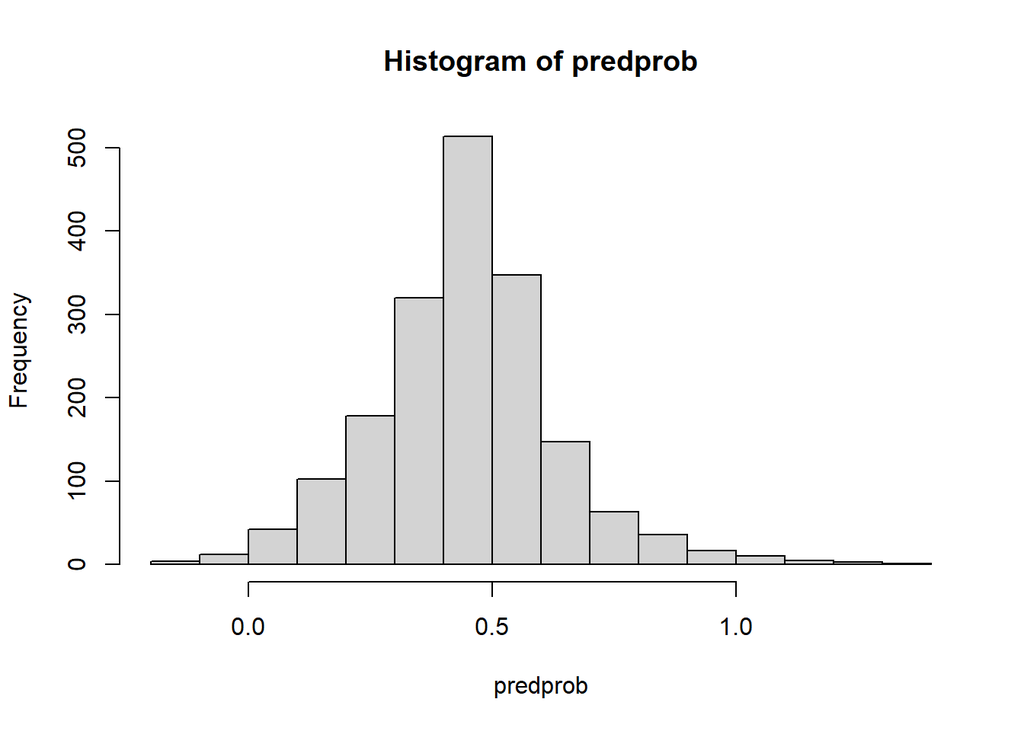

```r
train <- dat[r,]
test <- dat[-r,]

#linear model
linear <- lm(recidivate ~ ., dat = train)
predprob = predict(linear, test, type = "response")

hist(predprob)
```

As you can see, linear regression does not use standard probability or log odds when evaluating binary outcomes. This leads to probability predictions that are below 0 which do not make sense. Therefore, we expect linear regression to be the worst performing algorithm.

Next, we will test for the optimal cutoff point for the predicted probabilities of identifying a prediction as 1 (recidivate) or 0 (not recidivate).

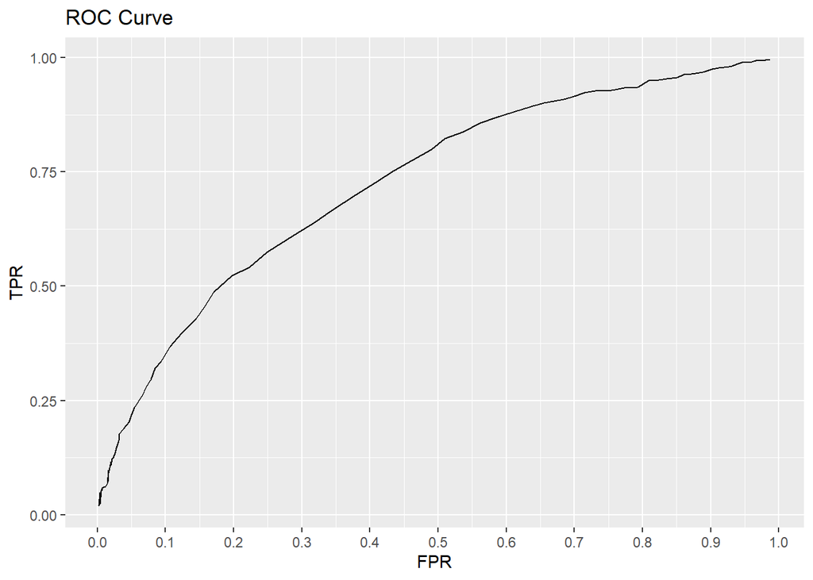

```r
y = test$recidivate


# we will test multiple cutoff points for classifying a prediction as 1 or 0. we will do this with a for loop of "t values" and then plot graphs that evaluate metrics for each cutoff value

index <- seq(1:101)
t_values <- seq(0,1,by = .01)

accuracy <- rep(NA, 101)
precision <- rep(NA, 101)
recall <- rep(NA, 101)

TPR <- rep(NA, 101)
FPR <- rep(NA, 101)
for(i in index){
  predict <- predprob > t_values[i]
  predict[predict] <- 1

  y_hat <- predict
  FP <- sum(y == 0 & y_hat == 1)
  FN <- sum(y == 1 & y_hat == 0)
  TP <- sum(y == 1 & y_hat == 1)
  TN <- sum(y == 0 & y_hat == 0)

  FPR[i] <- FP/(FP + TN)
  TPR[i] <- TP/(TP + FN)
  accuracy[i] <- (TP + TN)/(TP + TN + FP + FN)
  recall[i] <- TP/(TP + FN)
  precision[i] <- TP/(TP + FP)




}

metrics <- data.frame(t_values,FPR,TPR,accuracy,precision,recall)


qplot(FPR, TPR, geom = "line") + scale_x_continuous("FPR",breaks = seq(0,1,.1)) + ggtitle("ROC Curve")
```

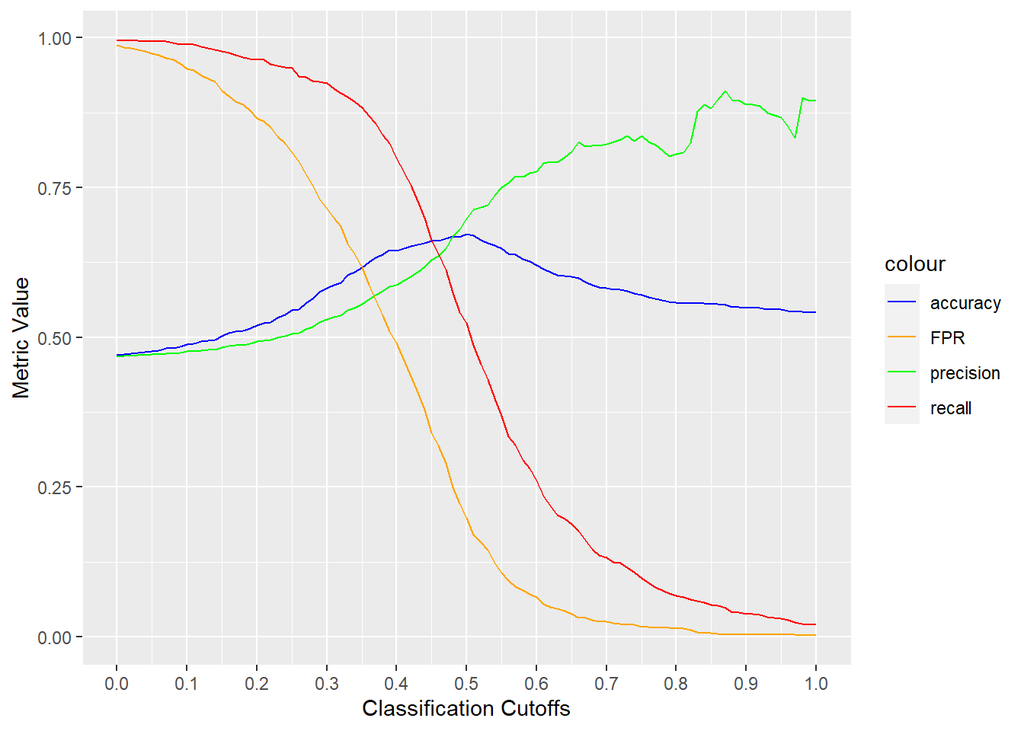

```r
colors <- c("accuracy" = "blue", "precision" = "green", "recall" = "red", "FPR" = "orange")
ggplot() + geom_line(aes(metrics$t_values, metrics$accuracy, color = "accuracy")) + geom_line(aes(metrics$t_values, metrics$precision, color = "precision")) + geom_line(aes(metrics$t_values, metrics$recall, color = "recall")) + geom_line(aes(metrics$t_values, metrics$FPR, color = "FPR")) + scale_color_manual(values = colors) + scale_x_continuous("Classification Cutoffs", breaks = seq(0,1,.1)) + ylab("Metric Value")
```

The ideal point appears to be 0.45 which has a false positive rate of 0.34 which puts the model at the idea spot on the ROC curve. The top left of the curve tries to maxmize the TPR while minimizing the FPR.

```r
linear_metrics <- metrics[metrics$t_values == 0.45,]
paste("Linear Model at 0.45 cutoff")
linear_metrics
```

```
## [1] "Linear Model at 0.45 cutoff"
##    t_values       FPR       TPR  accuracy precision    recall
## 46     0.45 0.3413111 0.6626937 0.6605556 0.6289593 0.6626937
```

## Logistic Regression

Logistic regression is designed to evalaute binary outcomes based on a set of predictors. Although there is no penalty function like ridge or lasso, logistic regression is the default algorithm for measuring binary otucomes.

However, we do not expect a logistic model to perform as well as a lasso or ridge sicne we expect that some features in the data are not good at predicting recidivism. Since logistic does not penalize any features, the model will pick up a lot of noise compared to lasso or ridge.

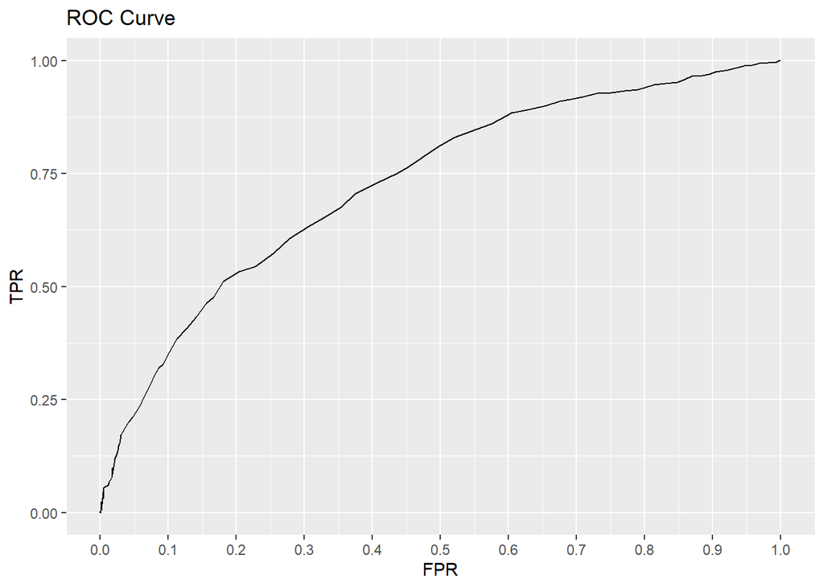

```r
# seperate into train and test data
train <- dat[r,]
test <- dat[-r,]

#model
logit <- glm(recidivate ~ ., data = train, family = binomial)

y = test$recidivate
predprob = predict(logit, test, type = "response")


# we will test multiple cutoff points for classifying a prediction as 1 or 0. we will do this with a for loop of "t values" and then plot graphs that evaluate metrics for each cutoff value

index <- seq(1:101)
t_values <- seq(0,1,by = .01)

accuracy <- rep(NA, 101)
precision <- rep(NA, 101)
recall <- rep(NA, 101)

TPR <- rep(NA, 101)
FPR <- rep(NA, 101)
for(i in index){
  predict <- predprob > t_values[i]
  predict[predict] <- 1

  y_hat <- predict
  FP <- sum(y == 0 & y_hat == 1)
  FN <- sum(y == 1 & y_hat == 0)
  TP <- sum(y == 1 & y_hat == 1)
  TN <- sum(y == 0 & y_hat == 0)

  FPR[i] <- FP/(FP + TN)
  TPR[i] <- TP/(TP + FN)
  accuracy[i] <- (TP + TN)/(TP + TN + FP + FN)
  recall[i] <- TP/(TP + FN)
  precision[i] <- TP/(TP + FP)




}

metrics <- data.frame(t_values,FPR,TPR,accuracy,precision,recall)


qplot(FPR, TPR, geom = "line") + scale_x_continuous("FPR",breaks = seq(0,1,.1)) + ggtitle("ROC Curve")
```

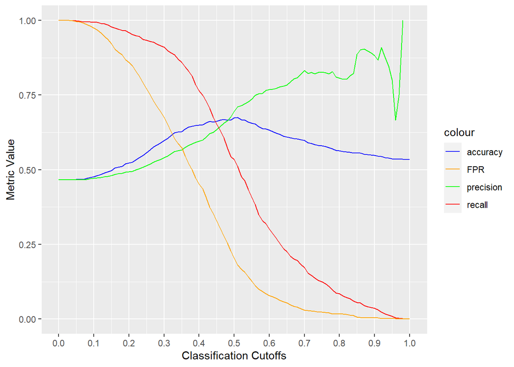

```r
colors <- c("accuracy" = "blue", "precision" = "green", "recall" = "red", "FPR" = "orange")
ggplot() + geom_line(aes(metrics$t_values, metrics$accuracy, color = "accuracy")) + geom_line(aes(metrics$t_values, metrics$precision, color = "precision")) + geom_line(aes(metrics$t_values, metrics$recall, color = "recall")) + geom_line(aes(metrics$t_values, metrics$FPR, color = "FPR")) + scale_color_manual(values = colors) + scale_x_continuous("Classification Cutoffs", breaks = seq(0,1,.1)) + ylab("Metric Value")
```

Since we are treating the cost of finding a false positive as equal to the cost of finding a false negative, we are going to treat all of our evaluation metrics as equal and try to find the ideal cutoff. Based on the ROC curve and the binary classification graph, we believe that the optimal cutoff is 0.45 since it has nearly the highest accuracy, a relatively low FPR, and keeps recall high.

```r
metrics_logistic <- metrics[metrics$t_values == 0.45,]
paste("Metrics at 0.45 cutoff:")
metrics_logistic
```

```
## [1] "Metrics at 0.45 cutoff:"
##    t_values       FPR       TPR  accuracy precision    recall
## 46     0.45 0.3288241 0.6531585 0.6627778 0.6342593 0.6531585
```

The FPR of a cutoff of 0.45 is 0.33 which is in the ideal spot of our ROC graph. We are sacrificing an optimal precision value, but there is a high cost to recall for getting better precision values. Again, we are trying to optimize between all metrics.

## Lasso Regression

Some of the features in the logistic model may not be relevant in predicting recidivism. This were the lasso model will come in. The lasso model will reduce the coefficients of irrelevant predictors to reduce their impact on predictions. In cases where the predictor is completely irrelevant, they will be reduced to 0.

First, we will run a cross validation model with 5 folds and a manual set of lamda values. The cross validation procedure to see how the model does when we resample the train and test set. The set of lamdas is to determine which lamda is ideal for the penalty function of the lasso which reduces the irrelevant coeficients. Then, we will select the lamda that minimizes the mean cross validated error and create a lasso model with lamda set to the optimal lamda.

Note that Lasso did not appear to be creating dummy variables for the categorical variables so we did it ourselves with model.matrix. The same process will be done for ridge regression.

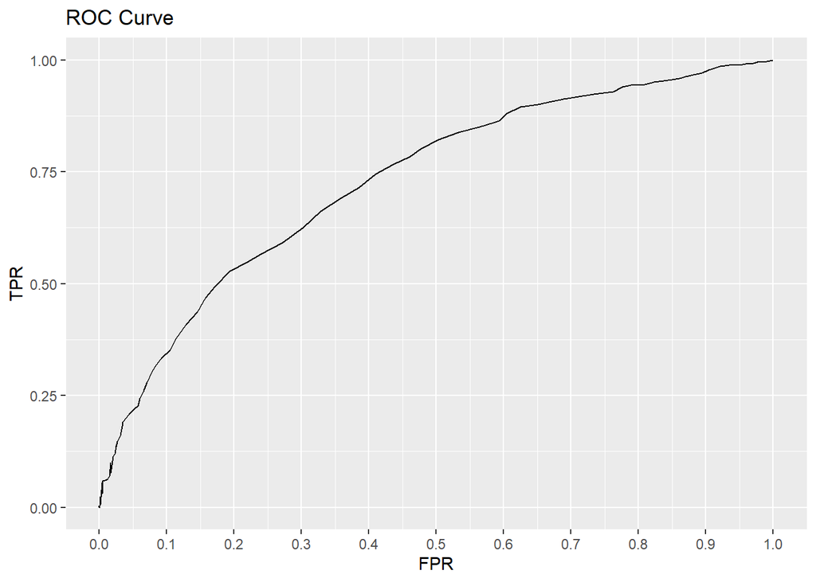

```r
dat <- read.csv("C:/Users/garmo/Downloads/recidivism_data_sample.csv")
dat <- dat[,-1]
dat$race <- factor(dat$race)
dat$charge_name <- factor(dat$charge_name)

# dummy code categorical variables
xfactors <- model.matrix(~ dat$race + dat$charge_name)

#convert back to dataframe
xfactors <- data.frame(xfactors)

#remove categorical variables from data
drops <- c("race","charge_name")
dat <- dat[,!names(dat) %in% drops]

#combine variables with categorical variables
x <- data.frame(dat,xfactors)
x <- data.matrix(subset(x, select = -recidivate))

y <- as.vector(dat$recidivate)
n.total <- length(y)
prop.train <- 0.7
set.seed(1)
r <- sample(1:n.total,round(prop.train*n.total), replace = FALSE)
x.train <- x[r,]
x.test <- x[-r,]
y.train <- y[r]
y.test <- y[-r]

lambdas <- 10^seq(from = 6, to = -2, length = 100)
mod <- cv.glmnet(x = x.train, y = y.train, nfold= 5, family = 'binomial',alpha = 1, lambdas = lamdas)

# now fit the optimal lamda

lasso.fit <- glmnet(x = x.train, y = y.train,
                    family = "binomial", alpha = 1, lambda = mod$lambda.min)

predprob = predict(lasso.fit, as.matrix(x.test), type = "response")
y <- y.test

index <- seq(1:101)
t_values <- seq(0,1,by = .01)

accuracy <- rep(NA, 101)
precision <- rep(NA, 101)
recall <- rep(NA, 101)

TPR <- rep(NA, 101)
FPR <- rep(NA, 101)
for(i in index){
  predict <- predprob > t_values[i]
  predict[predict] <- 1

  y_hat <- predict
  FP <- sum(y == 0 & y_hat == 1)
  FN <- sum(y == 1 & y_hat == 0)
  TP <- sum(y == 1 & y_hat == 1)
  TN <- sum(y == 0 & y_hat == 0)

  FPR[i] <- FP/(FP + TN)
  TPR[i] <- TP/(TP + FN)
  accuracy[i] <- (TP + TN)/(TP + TN + FP + FN)
  recall[i] <- TP/(TP + FN)
  precision[i] <- TP/(TP + FP)




}

metrics <- data.frame(t_values,FPR,TPR,accuracy,precision,recall)


qplot(FPR, TPR, geom = "line") + scale_x_continuous("FPR",breaks = seq(0,1,.1)) + ggtitle("ROC Curve")
```

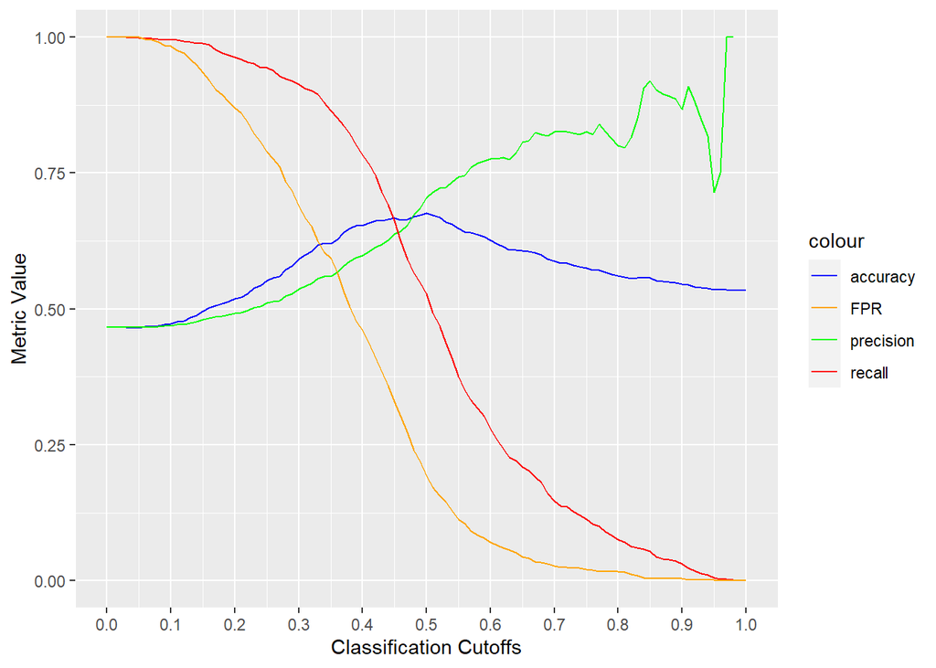

```r
colors <- c("accuracy" = "blue", "precision" = "green", "recall" = "red", "FPR" = "orange")
ggplot() + geom_line(aes(metrics$t_values, metrics$accuracy, color = "accuracy")) + geom_line(aes(metrics$t_values, metrics$precision, color = "precision")) + geom_line(aes(metrics$t_values, metrics$recall, color = "recall")) + geom_line(aes(metrics$t_values, metrics$FPR, color = "FPR")) + scale_color_manual(values = colors) + scale_x_continuous("Classification Cutoffs", breaks = seq(0,1,.1)) + ylab("Metric Value")
```

```r
paste("Area under ROC curve:", auc(roc(y.test,predprob)))
```

```
## [1] "Area under ROC curve: 0.731223931170228"
```

Now we will run a model with the lamda that is one standard error away from the min lamda, also known as lamda lse.

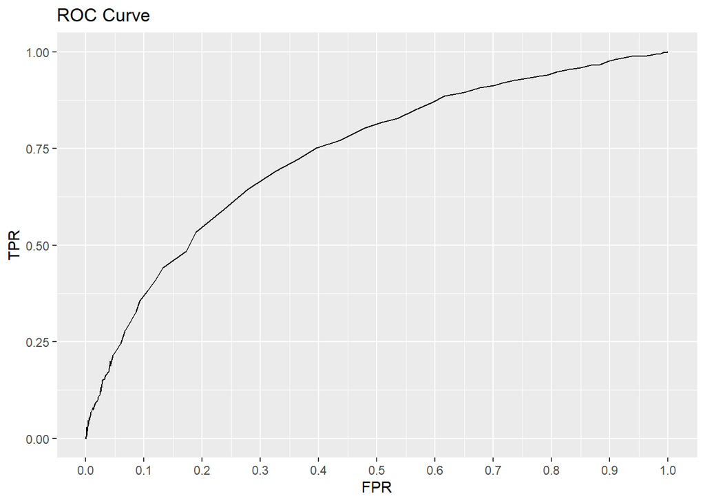

```r
lse <- mod$lambda.1se
lasso.fit <- glmnet(x = x.train, y = y.train,
                    family = "binomial", alpha = 1, lambda = lse)

predprob <- predict(lasso.fit, as.matrix(x.test), type = "response")
y <- y.test

index <- seq(1:101)
t_values <- seq(0,1,by = .01)

accuracy <- rep(NA, 101)
precision <- rep(NA, 101)
recall <- rep(NA, 101)

TPR <- rep(NA, 101)
FPR <- rep(NA, 101)
for(i in index){
  predict <- predprob > t_values[i]
  predict[predict] <- 1

  y_hat <- predict
  FP <- sum(y == 0 & y_hat == 1)
  FN <- sum(y == 1 & y_hat == 0)
  TP <- sum(y == 1 & y_hat == 1)
  TN <- sum(y == 0 & y_hat == 0)

  FPR[i] <- FP/(FP + TN)
  TPR[i] <- TP/(TP + FN)
  accuracy[i] <- (TP + TN)/(TP + TN + FP + FN)
  recall[i] <- TP/(TP + FN)
  precision[i] <- TP/(TP + FP)




}

metrics <- data.frame(t_values,FPR,TPR,accuracy,precision,recall)


qplot(FPR, TPR, geom = "line") + scale_x_continuous("FPR",breaks = seq(0,1,.1)) + ggtitle("ROC Curve")
```

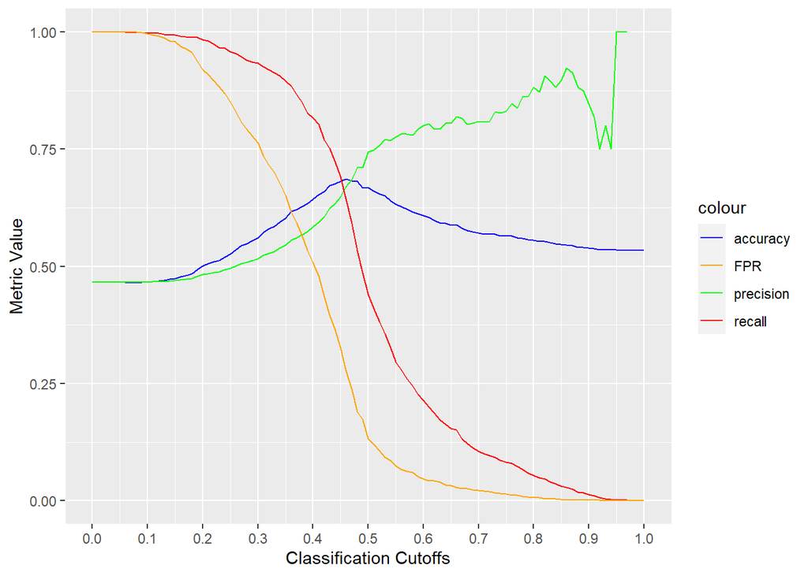

```r
colors <- c("accuracy" = "blue", "precision" = "green", "recall" = "red", "FPR" = "orange")
ggplot() + geom_line(aes(metrics$t_values, metrics$accuracy, color = "accuracy")) + geom_line(aes(metrics$t_values, metrics$precision, color = "precision")) + geom_line(aes(metrics$t_values, metrics$recall, color = "recall")) + geom_line(aes(metrics$t_values, metrics$FPR, color = "FPR")) + scale_color_manual(values = colors) + scale_x_continuous("Classification Cutoffs", breaks = seq(0,1,.1)) + ylab("Metric Value")
```

```r
paste("Area under ROC curve:", auc(roc(y.test,predprob)))
```

```
## [1] "Area under ROC curve: 0.738862106045178"
```

The lamda that minimizes the mean cross validated error has a lower area under ROC curve than the lamda that is within one standard error of that minimum. Therefore, the final lasso model will use the lse value as lamda in the loss function.

The ideal cutoff point again appears to be 0.45 as accuracy, precision, and recall all nearly intersect at that point.

## Lasso model using lse as lamda

```r
lasso.fit <- glmnet(x = x.train, y = y.train,
                    family = "binomial", alpha = 1, lambda = lse)
predprob <- predict(lasso.fit, as.matrix(x.test), type = "response")
y <- y.test

predict <- predprob > 0.45
predict[predict] <- 1

y_hat <- predict
FP <- sum(y == 0 & y_hat == 1)
FN <- sum(y == 1 & y_hat == 0)
TP <- sum(y == 1 & y_hat == 1)
TN <- sum(y == 0 & y_hat == 0)

FPR <- FP/(FP + TN)
TPR <- TP/(TP + FN)
accuracy <- (TP + TN)/(TP + TN + FP + FN)
recall <- TP/(TP + FN)
precision <- TP/(TP + FP)

metrics <- data.frame(t_values,FPR,TPR,accuracy,precision,recall)

paste("Metrics at 0.45 cutoff")
metrics_lasso <- metrics[metrics$t_values == 0.45,]
metrics_lasso
```

```
## [1] "Metrics at 0.45 cutoff"
##    t_values      FPR       TPR  accuracy precision    recall
## 46     0.45 0.326743 0.6912992 0.6816667 0.6487696 0.6912992
```

## Ridge Regression

Ridge is similar to lasso as it will reduce the coeficients of irrelevant predictors. However, it will not reduce them to 0 which may mean that ridge picks up more noise (or possibly more signal) than lasso.

The process will be almost identical to the lasso model.

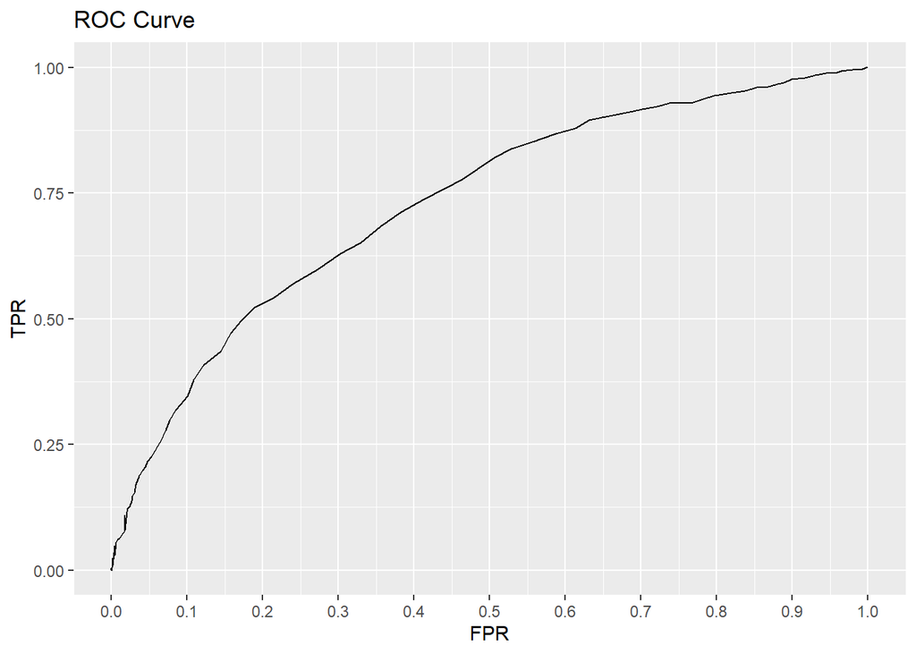

```r
dat <- read.csv("C:/Users/garmo/Downloads/recidivism_data_sample.csv")
dat <- dat[,-1]
dat$race <- factor(dat$race)
dat$charge_name <- factor(dat$charge_name)

# dummy code categorical variables
xfactors <- model.matrix(~ dat$race + dat$charge_name)

#convert back to dataframe
xfactors <- data.frame(xfactors)

#remove categorical variables from data
drops <- c("race","charge_name")
dat <- dat[,!names(dat) %in% drops]

#combine variables with categorical variables
x <- data.frame(dat,xfactors)
x <- data.matrix(subset(x, select = -recidivate))

y <- as.vector(dat$recidivate)
n.total <- length(y)
prop.train <- 0.7
set.seed(1)
r <- sample(1:n.total,round(prop.train*n.total), replace = FALSE)
x.train <- x[r,]
x.test <- x[-r,]
y.train <- y[r]
y.test <- y[-r]

lambdas <- 10^seq(from = 6, to = -2, length = 100)
mod <- cv.glmnet(x = x.train, y = y.train, nfold= 5, family = 'binomial',alpha = 0, lambdas = lamdas)

# now fit the optimal lamda

ridge.fit <- glmnet(x = x.train, y = y.train,
                    family = "binomial", alpha = 0, lambda = mod$lambda.min)

predprob = predict(ridge.fit, as.matrix(x.test), type = "response")
y <- y.test

index <- seq(1:101)
t_values <- seq(0,1,by = .01)

accuracy <- rep(NA, 101)
precision <- rep(NA, 101)
recall <- rep(NA, 101)

TPR <- rep(NA, 101)
FPR <- rep(NA, 101)
for(i in index){
  predict <- predprob > t_values[i]
  predict[predict] <- 1

  y_hat <- predict
  FP <- sum(y == 0 & y_hat == 1)
  FN <- sum(y == 1 & y_hat == 0)
  TP <- sum(y == 1 & y_hat == 1)
  TN <- sum(y == 0 & y_hat == 0)

  FPR[i] <- FP/(FP + TN)
  TPR[i] <- TP/(TP + FN)
  accuracy[i] <- (TP + TN)/(TP + TN + FP + FN)
  recall[i] <- TP/(TP + FN)
  precision[i] <- TP/(TP + FP)




}

metrics <- data.frame(t_values,FPR,TPR,accuracy,precision,recall)


qplot(FPR, TPR, geom = "line") + scale_x_continuous("FPR",breaks = seq(0,1,.1)) + ggtitle("ROC Curve")
```

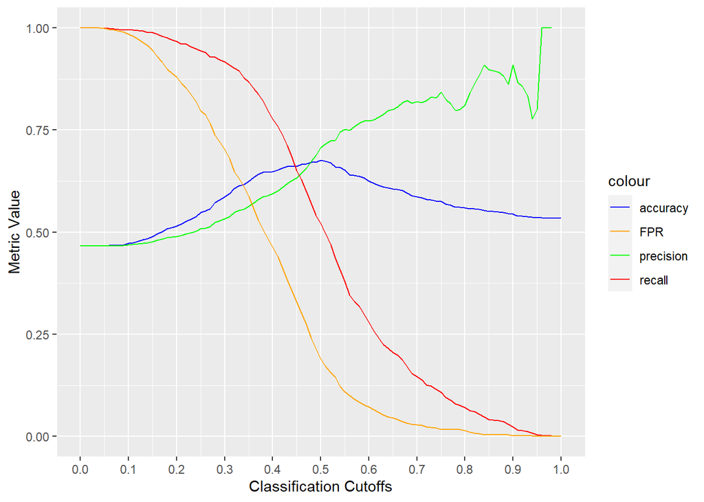

```r
colors <- c("accuracy" = "blue", "precision" = "green", "recall" = "red", "FPR" = "orange")
ggplot() + geom_line(aes(metrics$t_values, metrics$accuracy, color = "accuracy")) + geom_line(aes(metrics$t_values, metrics$precision, color = "precision")) + geom_line(aes(metrics$t_values, metrics$recall, color = "recall")) + geom_line(aes(metrics$t_values, metrics$FPR, color = "FPR")) + scale_color_manual(values = colors) + scale_x_continuous("Classification Cutoffs", breaks = seq(0,1,.1)) + ylab("Metric Value")
```

```r
paste("Area under ROC curve:", auc(roc(y.test,predprob)))
```

```
## [1] "Area under ROC curve: 0.73042085928072"
```

### Now using the lse value for lamda

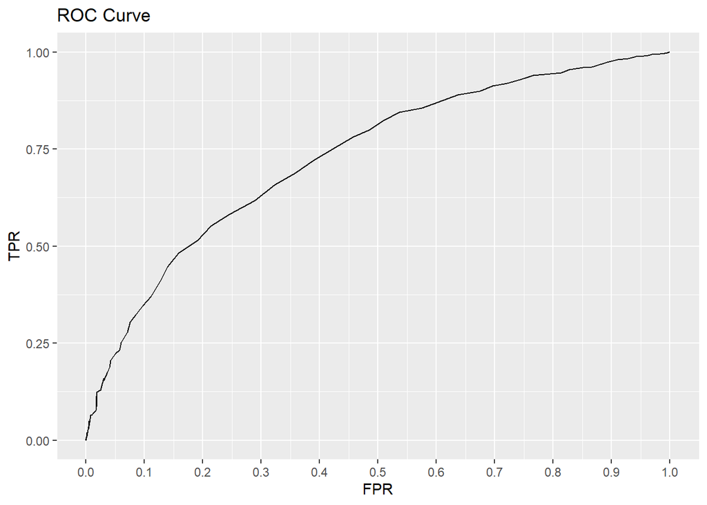

```r
lse <- mod$lambda.1se
lasso.fit <- glmnet(x = x.train, y = y.train,
                    family = "binomial", alpha = 0, lambda = lse)

predprob <- predict(lasso.fit, as.matrix(x.test), type = "response")
y <- y.test

index <- seq(1:101)
t_values <- seq(0,1,by = .01)

accuracy <- rep(NA, 101)
precision <- rep(NA, 101)
recall <- rep(NA, 101)

TPR <- rep(NA, 101)
FPR <- rep(NA, 101)
for(i in index){
  predict <- predprob > t_values[i]
  predict[predict] <- 1

  y_hat <- predict
  FP <- sum(y == 0 & y_hat == 1)
  FN <- sum(y == 1 & y_hat == 0)
  TP <- sum(y == 1 & y_hat == 1)
  TN <- sum(y == 0 & y_hat == 0)

  FPR[i] <- FP/(FP + TN)
  TPR[i] <- TP/(TP + FN)
  accuracy[i] <- (TP + TN)/(TP + TN + FP + FN)
  recall[i] <- TP/(TP + FN)
  precision[i] <- TP/(TP + FP)




}

metrics <- data.frame(t_values,FPR,TPR,accuracy,precision,recall)


qplot(FPR, TPR, geom = "line") + scale_x_continuous("FPR",breaks = seq(0,1,.1)) + ggtitle("ROC Curve")
```

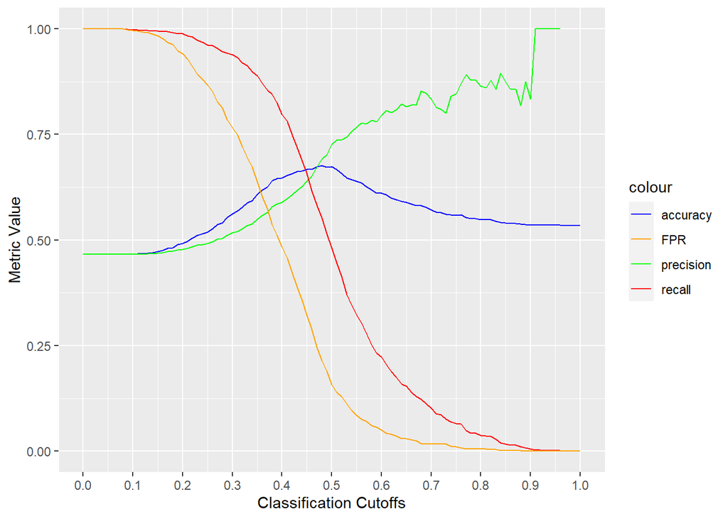

```r
colors <- c("accuracy" = "blue", "precision" = "green", "recall" = "red", "FPR" = "orange")
ggplot() + geom_line(aes(metrics$t_values, metrics$accuracy, color = "accuracy")) + geom_line(aes(metrics$t_values, metrics$precision, color = "precision")) + geom_line(aes(metrics$t_values, metrics$recall, color = "recall")) + geom_line(aes(metrics$t_values, metrics$FPR, color = "FPR")) + scale_color_manual(values = colors) + scale_x_continuous("Classification Cutoffs", breaks = seq(0,1,.1)) + ylab("Metric Value")
```

```r
paste("Area under ROC curve:", auc(roc(y.test,predprob)))
```

```
## [1] "Area under ROC curve: 0.731916619433224"
```

The lse lamda value leads to a very slight increase in area under ROC curve. We will use the lse lamda for our final ridge model.

In addition, the ideal cutoff point again appears to be 0.45.

```r
ridge.fit <- glmnet(x = x.train, y = y.train,
                    family = "binomial", alpha = 0, lambda = lse)
predprob <- predict(ridge.fit, as.matrix(x.test), type = "response")
y <- y.test

predict <- predprob > 0.45
predict[predict] <- 1

y_hat <- predict
FP <- sum(y == 0 & y_hat == 1)
FN <- sum(y == 1 & y_hat == 0)
TP <- sum(y == 1 & y_hat == 1)
TN <- sum(y == 0 & y_hat == 0)

FPR <- FP/(FP + TN)
TPR <- TP/(TP + FN)
accuracy <- (TP + TN)/(TP + TN + FP + FN)
recall <- TP/(TP + FN)
precision <- TP/(TP + FP)

metrics <- data.frame(t_values, FPR,TPR,accuracy,precision,recall)

paste("Ridge regression metrics:")
metrics_ridge <- metrics[metrics$t_values == 0.45,]
metrics_ridge
```

```
## [1] "Ridge regression metrics:"
##    t_values       FPR       TPR  accuracy precision    recall
## 46     0.45 0.3236212 0.6579261 0.6677778 0.6396292 0.6579261
```

## Final Model

Let’s compare the relevant metrics (as mentioned in intro) of all models.

```r
paste("Linear")
linear_metrics
paste("Logistic")
metrics_logistic
paste("Lasso")
metrics_lasso
paste("Ridge")
metrics_ridge
```

```
## [1] "Linear"
##    t_values       FPR       TPR  accuracy precision    recall
## 46     0.45 0.3413111 0.6626937 0.6605556 0.6289593 0.6626937
## [1] "Logistic"
##    t_values       FPR       TPR  accuracy precision    recall
## 46     0.45 0.3288241 0.6531585 0.6627778 0.6342593 0.6531585
## [1] "Lasso"
##    t_values      FPR       TPR  accuracy precision    recall
## 46     0.45 0.326743 0.6912992 0.6816667 0.6487696 0.6912992
## [1] "Ridge"
##    t_values       FPR       TPR  accuracy precision    recall
## 46     0.45 0.3236212 0.6579261 0.6677778 0.6396292 0.6579261
```

## Final Prediction

Please import file where “new” is. I created dummy variables when doing lasso.

```r
new <- read.csv("C:/Users/garmo/Downloads/recidivism_data_pseudo_new.csv")

dat <- new

dat$race <- factor(dat$race)
dat$charge_name <- factor(dat$charge_name)

# dummy code categorical variables
xfactors <- model.matrix(~ dat$race + dat$charge_name)

#convert back to dataframe
xfactors <- data.frame(xfactors)

#remove categorical variables from data
drops <- c("race","charge_name")
dat <- dat[,!names(dat) %in% drops]

#combine variables with categorical variables
x <- data.frame(dat,xfactors)
x <- data.matrix(x)


predprob <- predict(lasso.fit, x, type = "response")

head(predprob)
```

```
##          s0
## 1 0.3483041
## 2 0.3213196
## 3 0.3244477
## 4 0.5069717
## 5 0.3462593
## 6 0.5188280
```